# FJUEL workshop Dynamic documents in R: Introduction to Quarto

Session 2: Exploring dataframes, creating tables and graphs

# Session 2: Learning goals

### Learning goals

- Learn the basics of working with data frames in R
- Understand what piping means
- Create tables using the `{dplyr}` package
- Create graphs using `{ggplot2}`

# Action: Explore `PhDPublications` dataset

### Get data

- Install the `AER` package (that’s where the data are)

```r
install.packages("AER")
```

Load the packages `AER` and `tidyverse`:

```r
library(AER)
library(tidyverse)
```

- Run following code to be able to use the data set:

```r
data(PhDPublications)
```

- Data set appears as an object in your **workspace** (top right panel)

### Save typing

- Assign data frame to a new object called `d` (= copy it)
- Assignment operator:
  - `<-`
  - shortcut: Alt + - (Mac: Option + -)

```r
d <- PhDPublications
```

- RStudio also offers code completion: Tab key
- Try it: Type `Ph` and hit Tab key

### Inspect contents of data frame

- Contents: `str()`
- Look at first few rows: `head()`

### Inspect contents of data frame

- Variables
  - `articles` # articles published during last 3 years of PhD
  - `gender`
  - `married`
  - `kids` # of children less than 6 years old
  - `prestige` prestige of graduate program
  - `mentor` # articles published by mentor

### Inspect contents of data frame

```
'data.frame':   915 obs. of  6 variables:
 $ articles: int  0 0 0 0 0 0 0 0 0 0 ...
 $ gender  : Factor w/ 2 levels "male","female": 1 2 2 1 2 2 2 1 1 2 ...
 $ married : Factor w/ 2 levels "no","yes": 2 1 1 2 1 2 1 2 1 2 ...
 $ kids    : int  0 0 0 1 0 2 0 2 0 0 ...
 $ prestige: num  2.52 2.05 3.75 1.18 3.75 ...
 $ mentor  : int  7 6 6 3 26 2 3 4 6 0 ...
 - attr(*, "datalabel")= chr "Academic Biochemists / S Long"
 - attr(*, "time.stamp")= chr "30 Jan 2001 10:49"
 - attr(*, "formats")= chr [1:6] "%9.0g" "%9.0g" "%9.0g" "%9.0g" ...
 - attr(*, "types")= int [1:6] 98 98 98 98 102 98
 - attr(*, "val.labels")= chr [1:6] "" "sexlbl" "marlbl" "" ...
 - attr(*, "var.labels")= chr [1:6] "Articles in last 3 yrs of PhD" "Gender: 1=female 0=male" "Married: 1=yes 0=no" "Number of children < 6" ...
 - attr(*, "version")= int 6
 - attr(*, "label.table")=List of 6
  ..$ marlbl: Named num [1:2] 0 1
  .. ..- attr(*, "names")= chr [1:2] "Single" "Married"
  ..$ sexlbl: Named num [1:2] 0 1
  .. ..- attr(*, "names")= chr [1:2] "Men" "Women"
  ..$       : NULL
  ..$       : NULL
  ..$       : NULL
  ..$       : NULL
```

### Structure your Quarto document

- Use headings
  - `### R setup` (load packages)
  - `### Data` (load data)
  - `### Initial data analysis` (tables, graphs)
- Keyboard shortcut to insert code chunk:
  - Ctrl + Alt + I (Mac: Command + Option + I)

# Create tables

### R package: `dplyr`

- Part of the `tidyverse`
- Piping
  - `|>`
  - This code means “and then”
  - Shortcut: Strg + Shift + M (Mac: Cmd + Shift + M)

[figure not shown]

### How many male and female PhD students?

- Useful functions
  - `group_by()` divide the dataset
  - `summarize()` summarize subsets
  - `n()` count how many there are

```r
d |>
  group_by(gender) |>
  summarise(
    N = n())
```

```
# A tibble: 2 × 2
  gender     N
  <fct>  <int>
1 male     494
2 female   421
```

### Task

- Create tables to answer the following questions
- How many PhD students…
  - … are married?
  - … have no kids?

### Number of articles by kid count

- `mean()`, `median()`, `sd()`, `max()`

```r
d |>
  group_by(kids) |>
  summarise(
    N = n(),
    mean_pubs = mean(articles),
    median_pubs = median(articles),
    sd_pubs = sd(articles),
    max_pubs = max(articles))
```

```
# A tibble: 4 × 6
   kids     N mean_pubs median_pubs sd_pubs max_pubs
  <int> <int>     <dbl>       <dbl>   <dbl>    <int>
1     0   599     1.72            1   1.93        19
2     1   195     1.76            1   2.05        12
3     2   105     1.54            1   1.74        11
4     3    16     0.812           1   0.911        3
```

# Create graphs

### R package `ggplot2`

- Part of the `tidyverse`
- “Grammar of Graphics”

[figure not shown]

### How many PhD students have (how many) kids?

```r
d |> ggplot(aes(x = kids)) +
    geom_bar()
```

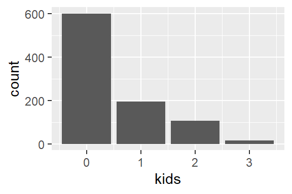

### How many PhD students are married?

```r
d |> ggplot(aes(x = married)) +
    geom_bar()
```

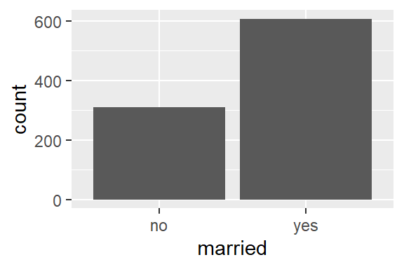

### Distribution: Number of articles published by mentor

```r
d |> ggplot(aes(x = mentor)) +
    geom_histogram()
```

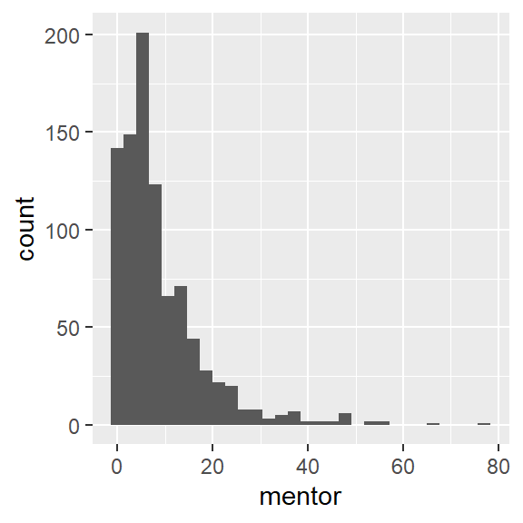

### Explore themes

```r
d |> ggplot(aes(x = mentor)) +
    geom_histogram() +
    theme_minimal()
```

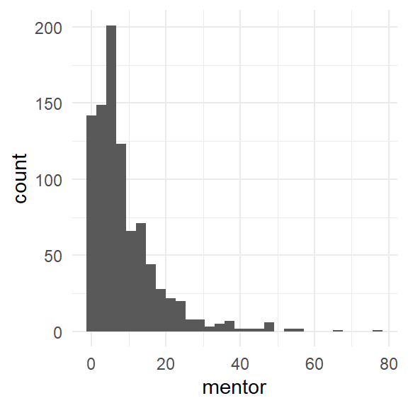

# Session 2: Practice

Time for practice! The tasks are available [here](https://lsoenning.github.io/resources_pages/practice_2.html). (there is also a link on my website)